# Homework 5 - BIOS 6643

Dominic Adducci

2023-09-28

# Question 1

Conduct a preliminary data investigation on the titer data. Analysis will be conducted on the log scale. Please make graphs on this scale. Include in your homework submission 2-3 graphs and a summary table that you believe describes the data. Interpret both the graphs and the summary data in a paragraph.

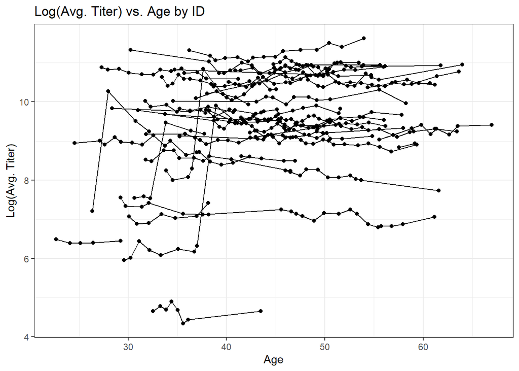

The above plot shows the relationship between the logged value of average measles antibody titer versus age, where each subject has their different time points connected by a line. In general there seems to be more variation between subjects compared to within subjects.

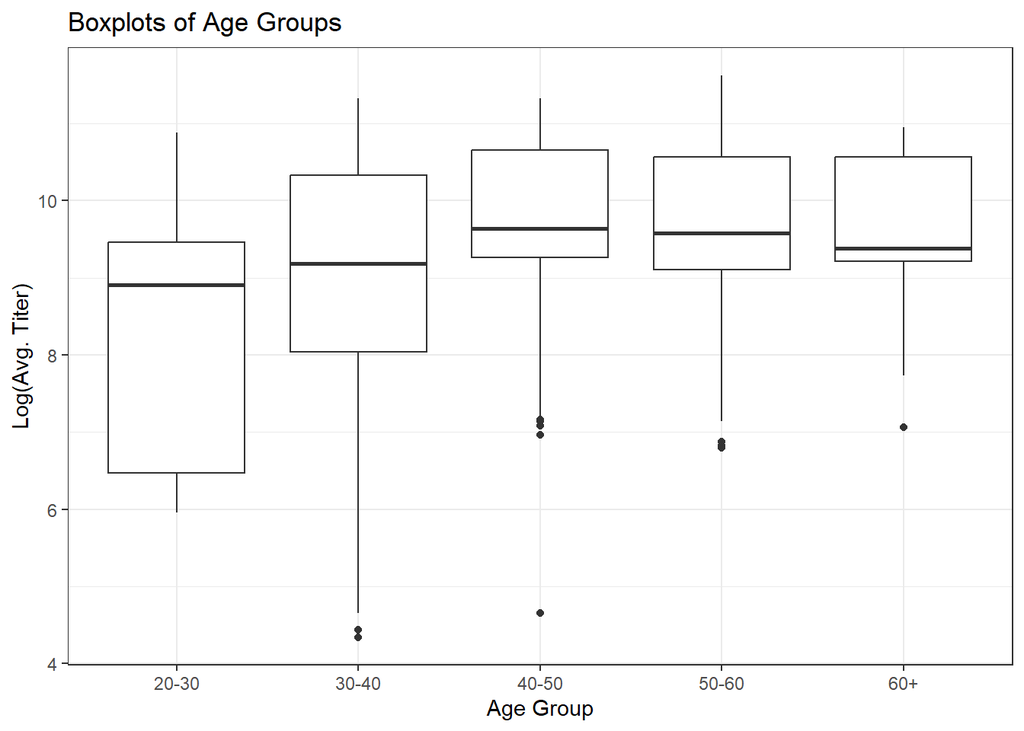

The plot above shows the boxplots of measles antibody titers for different age groups. The 20-30 age group has the lowest mean and widest interquartile range. Average titer increases until ages 40-50, after which it slightly decreases as age progresses. There is a stabilization of measles titers after subjects reach the age group of 40-50.

Table 1: Descriptive Statistics

|  | 20-30 (N=19) | 30-40 (N=119) | 40-50 (N=196) | 50-60 (N=105) | 60+ (N=15) | Overall (N=454) |
| --- | --- | --- | --- | --- | --- | --- |
| Avg_Titer_Log |  |  |  |  |  |  |
| Mean (SD) | 8.30 (1.73) | 8.91 (1.73) | 9.78 (0.984) | 9.66 (1.14) | 9.60 (1.14) | 9.46 (1.36) |
| Median [Min, Max] | 8.91 [5.96, 10.9] | 9.18 [4.34, 11.3] | 9.63 [4.65, 11.3] | 9.58 [6.80, 11.6] | 9.38 [7.06, 10.9] | 9.54 [4.34, 11.6] |

# Question 2: Random Intercept Model

#### Part A

Write out the random intercept model for these data in subject level notation including indices for matrices.

$$Y_i = X_i\beta + Z_ib_i + E_i$$
Where each matrix has the following dimensions:

- $Y_i: (n_i \times 1)$; $n_i$ refers to the number of time points (age). Outcome is the log of average titer.
- $X_i: (n_i \times p)$; $n_i$ refers to the number of time points(age) and p is the number of covariates plus the intercept. The only covariates are the number of time points (age).
- $\beta: (p \times 1)$; $p$ refers to the number of covariates (measurements at a certain age plus the intercept).
- $Z_i: (n_i \times q)$; $n_i$ refers to the number of time points (age). $q$ refers to the number of covariates for the random effects. In this case there is only a random intercept, so $q=1$.
- $b_i: (q \times 1)$; $q$ refers to the number of covariates for the random effects. In this case there is only one random intercept, so $q=1$.
- $E_i: (n_i \times 1)$; $n_i$ refers to the number of time points (age). Each individual outcome has its own error term.

#### Part B

What is the format for $G_i$ and $R_i$ that will be assumed in the lmer R function when you fit the random intercept model? Please write the format for these two matrices and interpret.

The variability of the random effect will be a matrix with $(q_i \times q_i)$ dimensions. Because there is only one random effect, the random intercept, this will be a matrix with a single element for all subjects.
$$G_i = [\tau_0^2] = [\sigma_0^2]$$
It is usually not possible to estimate both $G$ and an unstructured $R_i$, meaning that $R_i=\sigma_e^2I_n$ (an independence matrix). The dimensions of $R_i$ are $(n_i \times n_i)$, which in this case means a square matrix where $n_i$ is the number of time points (measurements at different ages) for each subject. Because different subjects have different time points the dimensions of the $R_i$ matrix will change between subjects.

#### Part C

Will $G_i$ and $R_i$ be the same dimension for each individual? Explain.

For $G_i$ the dimensions will be the same between all subjects because each subject only has a random intercept. The dimension of $G_i$ are $(q_i \times q_i)$, where $q_i$ refers to the number of random effects. Because this model only includes a random intercept $q_i$ will be equal to 1, and the matrix will simply contain a single element of $\tau_0^2=\sigma_0^2$.

$R_i$ will not be the same between subjects because there are different numbers of time points for each subject. The dimensions of $R_i$ are $(n_i \times n_i)$, where $n_i$ refers to the number of individual time points (age at sample collection).

#### Part D

Fit a random intercept model for these data using the lmer R function with REML and ML estimation approaches. Provide you code and output.

```r
### START QUESTION 2 CODE ###

## START QUESTION 2 Part D CODE ##

# Fitting a lmer model with a random intercept using the REML method
measles_ri_reml <- lmer(Avg_Titer_Log ~ Age_At_Draw + (1|ID),
                        data = measles_data, REML = TRUE)

summary(measles_ri_reml)
```

```
## Linear mixed model fit by REML. t-tests use Satterthwaite's method [
## lmerModLmerTest]
## Formula: Avg_Titer_Log ~ Age_At_Draw + (1 | ID)
##    Data: measles_data
##
## REML criterion at convergence: 524.2
##
## Scaled residuals:
##     Min      1Q  Median      3Q     Max
## -5.4095 -0.2623 -0.0105  0.2590  8.7896
##
## Random effects:
##  Groups   Name        Variance Std.Dev.
##  ID       (Intercept) 2.0834   1.4434
##  Residual             0.1154   0.3396
## Number of obs: 454, groups:  ID, 40
##
## Fixed effects:
##              Estimate Std. Error        df t value Pr(>|t|)
## (Intercept) 9.098e+00  2.735e-01 7.657e+01  33.267   <2e-16 ***
## Age_At_Draw 4.924e-03  3.388e-03 4.253e+02   1.453    0.147
## ---
## Signif. codes:  0 '***' 0.001 '**' 0.01 '*' 0.05 '.' 0.1 ' ' 1
##
## Correlation of Fixed Effects:
##             (Intr)
## Age_At_Draw -0.547
```

```r
# Fitting a lmer model with a random intercept using the ML method
measles_ri_ml <- lmer(Avg_Titer_Log ~ Age_At_Draw + (1|ID),
                        data = measles_data, REML = FALSE)

summary(measles_ri_ml)
```

```
## Linear mixed model fit by maximum likelihood . t-tests use Satterthwaite's
##   method [lmerModLmerTest]
## Formula: Avg_Titer_Log ~ Age_At_Draw + (1 | ID)
##    Data: measles_data
##
##      AIC      BIC   logLik deviance df.resid
##    521.5    538.0   -256.7    513.5      450
##
## Scaled residuals:
##     Min      1Q  Median      3Q     Max
## -5.4158 -0.2623 -0.0103  0.2596  8.7988
##
## Random effects:
##  Groups   Name        Variance Std.Dev.
##  ID       (Intercept) 2.0299   1.4247
##  Residual             0.1151   0.3392
## Number of obs: 454, groups:  ID, 40
##
## Fixed effects:
##              Estimate Std. Error        df t value Pr(>|t|)
## (Intercept) 9.097e+00  2.709e-01 7.949e+01  33.579   <2e-16 ***
## Age_At_Draw 4.950e-03  3.384e-03 4.266e+02   1.463    0.144
## ---
## Signif. codes:  0 '***' 0.001 '**' 0.01 '*' 0.05 '.' 0.1 ' ' 1
##
## Correlation of Fixed Effects:
##             (Intr)
## Age_At_Draw -0.551
```

```r
## FINISH QUESTION 2 PART D CODE ##
```

#### Part E

What are the fixed effects estimates with 95%CI and p-values for both fits? How do they compare? Explain.

| Term | Estimate | 95% Conf.Low | 95% Conf.High | P-Value |
| --- | --- | --- | --- | --- |
| **REML** |  |  |  |  |
| Intercept | 9.09765 | 8.55305 | 9.64226 | < 2e-16 |
| Age At Draw | 0.00492 | -0.00174 | 0.01158 | 0.14692 |
| **ML** |  |  |  |  |
| Intercept | 9.09653 | 8.55736 | 9.63569 | < 2e-16 |
| Age At Draw | 0.00495 | -0.00170 | 0.01160 | 0.14424 |

#### Part F

Interpret these findings in 1-2 sentences.

Both models have approximately the same output, different confidence intervals (see above for explanation). The intercept of 9.10 is the expected log of the average titer at age 0, which is significant in both models with p-values <0.001. The “Age At Draw” coefficient is the expected change in titer as age progresses each year, with the coefficient meaning there is an expected increase of 0.005 in log of titer each year. This coefficient is insignificant with a p-value >0.05.

#### Part G

What test was used to generate the p-value and what were the denominator DF?

For both the REML and ML methods the Satterthwaite’s method was used to generate the p-value. For the REML method the degrees of freedom for the intercept was 76.57 (closer to the number of subjects), and for the “Age At Draw” term it was 425.3 (Closer to the number of total observations). For the ML method the degrees of freedom for the intercept was 79.49 (closer to the number of subjects), and for the “Age at Draw” term it was 426.6 (closer to the number of observations).

#### Part H

Use the anova package to test the significance of the slope on age using a Satterwaithe and a Kenward-Roger DF adjustment. Present and compare the denominator DF. Provide a 1-2 sentence intuitive answer as to why they differ (or are similar). Were there any differences in your study conclusion using different tests?

DDF for Random Intercept - Different Methods

| Method | DDF | P-Value |
| --- | --- | --- |
| Satterthwaite | 425.274 | 0.147 |
| Kenward-Roger | 425.412 | 0.147 |

The DDF are nearly identical for the slope between the Satterthwaite and Kenward-Roger methods. The sample size may be sufficient to overcome the unbalanced data (where the Satterthwaite tends to performs worse). The p-values were the same to the third decimal place, meaning the same conclusion, that the slope is not significant in the random intercept model.

#### Part I

What were the estimates of $G_i$, $R_i$, and $V_i$ for this model using both approaches? Interpret the different sources of variation. What estimates will be more biased (ML and REML)? Why?

**REML**

**ML**

$G_i$ and $R_i$ are both from the model summary. $V_i$ is the summation of these two components:

- $G_i$ = 2.0299
- $R_i$ = $\sigma_e$ = 0.1151; This estimate will be in a matrix with the format $\sigma_e I_n$
- $V_i$ = Diagnoal= 2.1450; off diagonal = 2.0299; These estimates will be in a matrix with dimensions (nxn).

The estimates from the ML method will be more biased (downward). This is because the variance values are determined using the estimates of the means.

#### Part J

Compute the ICC and interpret. What source of variation is largest, within or between subject variation? $G_i$ is the between subject variation, $R_I$ is the within subject variation, and $V_i$ is the total variation for a specific subject.

**REML**

$$ICC =
\frac{\sigma_{b0}}{\sigma_{b0}+\sigma_e}=\frac{2.0834}{2.0834+0.1154}=0.948$$
In the REML method there is more between subject variation compared to within subject variation.

**ML**

$$ICC =
\frac{\sigma_{b0}}{\sigma_{b0}+\sigma_e}=\frac{2.0299}{2.0299+0.1151}=0.946$$
In the ML method there is more between subject variation compared to within subject variation.

#### Part K

Using the ML estimates, create the EBLUP and the fitted estimates. The individual fitted values of the outcome are a weighted combination of two quantities. What are these two quantities? What determines the weight of the individual estimate towards each of the quantities?

```r
## START QUESTION 2 PART K CODE ##

# Calculating the EBLUPs.
ri_eblup <- ranef(measles_ri_ml)

# Calculating the fitted estimates.
ri_fitted <- fitted(measles_ri_ml)

## FINISH QUESTION 2 PAT K CODE ##
```

The individual fitted values are a combination of subject specific data (random effects) and group averaged data. The weight of individual estimates is the difference between the population average profile and the observed data.

#### Part L

Make a plot of the estimated individual specific curves compared to the observed data. How well do you think this model is capturing the the variation in the data and the age trends in the data? Provide an interpretation in a few sentences.

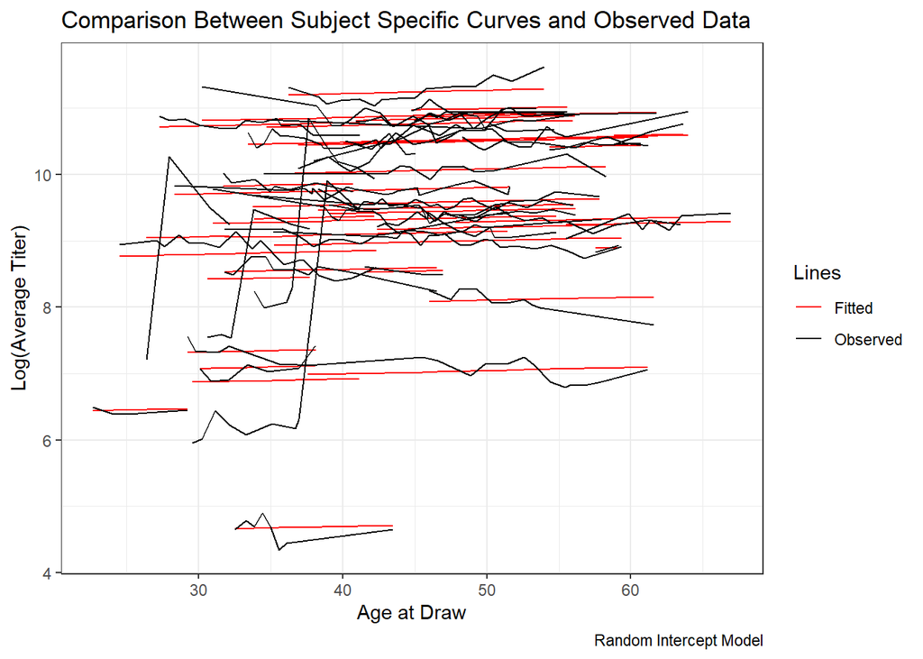

The plot is capturing the different starting values for each subject well, as there is a significant amount of variance between subjects which the average value does not show. Because there is less within subject variation the inclusion of only a random intercept still performs well.

# Question 3

#### Part A

Write out the random intercept model for these data in subject level notation including indices for matrices.

$$Y_i = X_i\beta + Z_ib_i + E_i$$
Where each matrix has the following dimensions:

- $Y_i: (n_i \times 1)$; $n_i$ refers to the number of time points (age). Outcome is the log of average titer.
- $X_i: (n_i \times p)$; $n_i$ refers to the number of time points(age) and p is the number of covariates plus the intercept. The only covariates are the number of time points (age).
- $\beta: (p \times 1)$; $p$ refers to the number of covariates (measurements at a certain age plus the intercept).
- $Z_i: (n_i \times q)$; $n_i$ refers to the number of time points (age). $q$ refers to the number of covariates for the random effects. In this case there is a random intercept and a random slope, so $q=2$.
- $b_i: (q \times 1)$; $q$ refers to the number of covariates for the random effects. In this case there is a random intercept and random slope, so $q=2$.
- $E_i: (n_i \times 1)$; $n_i$ refers to the number of time points (age). Each individual outcome has its own error term.

#### Part B

What is the format for $G_i$ and $R_i$ that will be assumed in the lmer R function when you fit the random intercept model? Please write the format for these two matrices and interpret. Note we want the random effects to have an unstructured $G_i$ matrix.

The variability of the random effect will be a matrix with $(q_i \times q_i)$ dimensions. Because there is a random intercept and a random slope the $G_i$ matrix will have dimensions of $(2 \times 2)$.
$$G_i =
\begin{bmatrix}
\tau_0^2 & \tau_{01} \\
\tau_{10} & \tau_1^2
\end{bmatrix}
=
\begin{bmatrix}
\sigma_0^2 & \sigma_{01} \\
\sigma_{10} & \sigma_1^2
\end{bmatrix}$$
It is usually not possible to estimate both $G$ and an unstructured $R_i$, meaning that $R_i=\sigma_e^2I_n$ (an independence matrix). The dimensions of $R_i$ are $(n_i \times n_i)$, which in this case means a square matrix where $n_i$ is the number of time points (measurements at different ages) for each subject. Because different subjects have different time points the dimensions of the $R_i$ matrix will change between subjects.

#### Part C

Fit a random intercept and slope model for these data using the lmer R function with REML and ML estimation approaches. Provide code and output.

```r
### START QUESTION 3 CODE ###

## START PART C CODE ##

# Fitting a lmer model with a random intercept and slope  using the REML method.
measles_ri_rs_reml <- lmer(Avg_Titer_Log ~ Age_At_Draw + (1 + Age_At_Draw|ID),
                        data = measles_raw, REML = TRUE,
                        control = lmerControl(optimizer = "bobyqa"))

summary(measles_ri_rs_reml)
```

```
## Linear mixed model fit by REML. t-tests use Satterthwaite's method [
## lmerModLmerTest]
## Formula: Avg_Titer_Log ~ Age_At_Draw + (1 + Age_At_Draw | ID)
##    Data: measles_raw
## Control: lmerControl(optimizer = "bobyqa")
##
## REML criterion at convergence: 364.7
##
## Scaled residuals:
##     Min      1Q  Median      3Q     Max
## -5.5705 -0.2587 -0.0076  0.2537  7.3821
##
## Random effects:
##  Groups   Name        Variance  Std.Dev. Corr
##  ID       (Intercept) 11.225751 3.3505
##           Age_At_Draw  0.006115 0.0782   -0.91
##  Residual              0.060513 0.2460
## Number of obs: 454, groups:  ID, 40
##
## Fixed effects:
##             Estimate Std. Error       df t value Pr(>|t|)
## (Intercept)  8.35466    0.56044 37.59941   14.91   <2e-16 ***
## Age_At_Draw  0.02602    0.01301 34.34728    2.00   0.0534 .
## ---
## Signif. codes:  0 '***' 0.001 '**' 0.01 '*' 0.05 '.' 0.1 ' ' 1
##
## Correlation of Fixed Effects:
##             (Intr)
## Age_At_Draw -0.917
```

```r
# Fitting a lmer model with a random intercept and slope using the ML method
measles_ri_rs_ml <- lmer(Avg_Titer_Log ~ Age_At_Draw + (1 + Age_At_Draw|ID),
                        data = measles_raw, REML = FALSE)

summary(measles_ri_rs_ml)
```

```
## Linear mixed model fit by maximum likelihood . t-tests use Satterthwaite's
##   method [lmerModLmerTest]
## Formula: Avg_Titer_Log ~ Age_At_Draw + (1 + Age_At_Draw | ID)
##    Data: measles_raw
##
##      AIC      BIC   logLik deviance df.resid
##    368.7    393.4   -178.4    356.7      448
##
## Scaled residuals:
##     Min      1Q  Median      3Q     Max
## -5.5893 -0.2578 -0.0075  0.2538  7.3893
##
## Random effects:
##  Groups   Name        Variance  Std.Dev. Corr
##  ID       (Intercept) 10.891284 3.30019
##           Age_At_Draw  0.005917 0.07692  -0.91
##  Residual              0.060546 0.24606
## Number of obs: 454, groups:  ID, 40
##
## Fixed effects:
##             Estimate Std. Error       df t value Pr(>|t|)
## (Intercept)  8.35606    0.55266 38.51190  15.120   <2e-16 ***
## Age_At_Draw  0.02597    0.01281 35.08650   2.027   0.0503 .
## ---
## Signif. codes:  0 '***' 0.001 '**' 0.01 '*' 0.05 '.' 0.1 ' ' 1
##
## Correlation of Fixed Effects:
##             (Intr)
## Age_At_Draw -0.917
```

```r
## FINISH QUESTION 3 PART C CODE ##
```

#### Part D

What are the fixed effects estimates with 95%CI and p-values for both fits? How do they compare? Explain.

| Term | Estimate | 95% Conf.Low | 95% Conf.High | P-Value |
| --- | --- | --- | --- | --- |
| **REML** |  |  |  |  |
| Intercept | 8.35466 | 7.21970 | 9.48961 | < 2e-16 |
| Age At Draw | 0.02602 | -0.00040 | 0.05244 | 0.053408 |
| **ML** |  |  |  |  |
| Intercept | 8.35606 | 7.23775 | 9.47437 | < 2e-16 |
| Age At Draw | 0.02597 | -0.00003 | 0.05197 | 0.050278 |

#### Part E

Interpret these finding in 1-2 sentences.

Both models have approximately the same outcomes. The intercept means that subjects at age 0 are expected to have a log of average titer of 8.36, which is significant with a p-value <0.001. The “Age at Draw” coefficient means that for every year subjects are expected to increase their log of average titer by 0.026. This estimate is insignificant in both models, with p-values > 0.05.

#### Part H

Use the anova package to test the significance of the slope on age using a Satterthwaite and a Kenward-Roger DF adjustment for the REML model. Present and compare the denominator DF. Provide a 1-2 sentence intuitive answer as to why they differ (or are similar). Were there any differences in your conclusions between these different testing approaches.

Random Intercept-Slope REML DF

| Method | DDF | P-Value |
| --- | --- | --- |
| Satterthwaite | 34.347 | 0.053 |
| Kenward-Roger | 38.433 | 0.053 |

The DDF for the Satterthwaite method is less than the Kenward-Roger method. Because a random slope was fitted the degrees of freedom in was closer to the number of subjects, as opposed to the random intercept only model which had a DDF closer to the number of observations. Due to unbalanced data between subjects the Kenward-Roger method should be chosen. The p-values are very close however, and neither is statistically significant.

#### Part I

Were there any differences between tests and denominator DF between the random intercept and random slope models? Explain.

Between the random intercept and random intercept/slope models neither p-values are significant. However, the p-values from the random intercept/slope models are much closer to the level of significance due to accounting for between subject variation in slopes. Between the random intercept and random intercept/slope models the degrees of freedom in the random intercept model is much higher and much closer to the number of observations. After accounting for between subject differences in slopes with the random slope/intercept model the DF are closer to the number of subjects.

#### Part J

What were the estimates of $G_i$, $R_i$, and $V_i$ for this model using both approaches? Interpret the different sources of variation. What estimates will be more biased (ML and REML)? Why?

All values were extracted from the model outputs.

**REML**

**ML**

#### Part K

Using the ML estimates, compute the ICC for the slope and interpret. What percentage of variation is due to the random effect on slope.

$$ICC(Slope) =
\frac{\sigma_{b1}^2}{\sigma_{b0}^2+\sigma_{b1}^2+\sigma_e^2}=\frac{0.005917}{10.891284+0.005917+0.060546}=5.3998
\times 10^{-4}$$
The ICC for slope is very small meaning that almost none of the variance is due to the random effect on slope. This means that there is not a lot of variance in the slopes between subjects.

$$ICC(Intercept) =
\frac{\sigma_{b0}^2}{\sigma_{b0}^2+\sigma_{b1}^2+\sigma_e^2}=\frac{10.891284}{10.891284+0.005917+0.060546}=0.994$$
The ICC for the intercept accounts for nearly all of the variance in the model. This means that there is a lot of variance in the intercepts between subjects. In other words, subjects start at vastly different average titer levels.

#### Part L

Using the ML estimates, create the EBLUP and the fitted estimates. There is nothing to turn in for this question but the code.

```r
## START QUESTION 3 PART L CODE ##

# Calculating the estimates. Converting to data.frame to extract the
ri_rs_eblups <- ranef(measles_ri_rs_ml,condVar = TRUE)

# Calculating the fitted values.
ri_rs_fitted <- fitted(measles_ri_rs_ml)

## FINISH QUESTION 3 PART L CODE ##
```

#### Part M

Make a plot of the estimated individual specific curves compared to the observed data. How well do you think this model is capturing the variation in the data and the age trends in the data? Provide an interpretation in a few sentences.

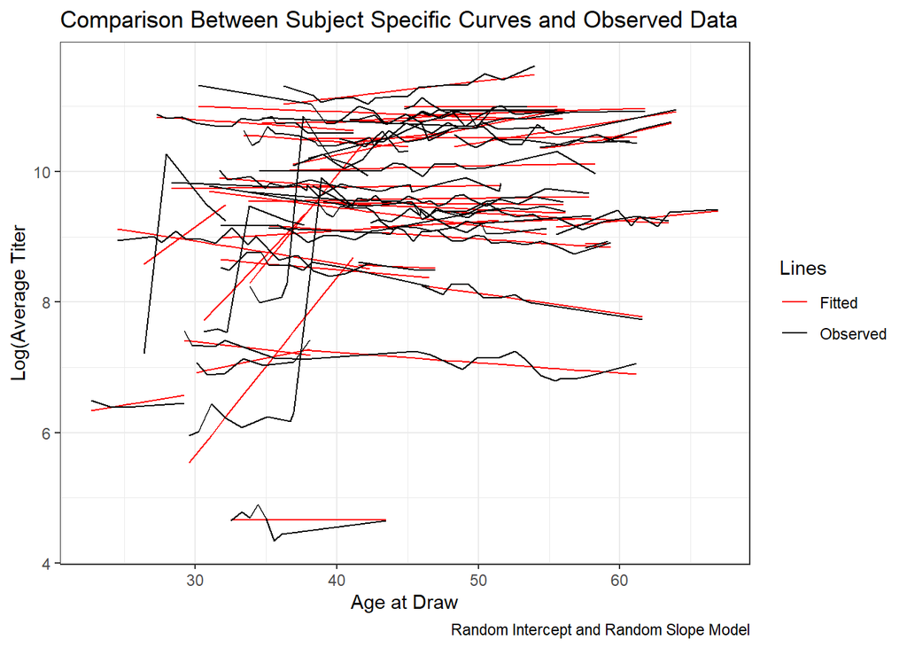

For each individual subject the random intercept/slope model more closely models the trend between age and the log of average titer. Most subjects have a roughly linear trend with time and the random slopes model these well, although a few subjects have trends which are not linear.

#### Part N

Base on the fits do you think the random slope is a critical additional component to add to the model? Explain.

Based on the ICC adding a random slope does not significantly account for variance within the model. From the plot of fitted values the fitted lines do better track with subject trends, but subjects vary enough along the y-axis that doing this does not significantly fit the model better.

#### Part O

The investigator is leery of these mixed effects models. How would you show him/her what the random intercept and random slope model did for estimation compared to just fitting a bunch of regression models, one for each person?

Using a random intercept/slope model allows for each subject to be modeled separately, which in effect provides the same inferences on subjects that fitting multiple regression models for each subject would. The random intercept/slope model also provides the average trends, which are what will be used for making inferences on people who have had measles vaccines.

# Part 2

[figure not shown]

## Question 3

#### Part A

Use a Poisson GLM (i.e. Poisson regression) to estimate the association between condition (group) and number of breakfast servings, adjusting for sex and weight.

Condition - Poisson Model - Exponentiated

| Term | Estimate | Std.Error | 95% Conf.Low | 95% Conf.High | P-Value |
| --- | --- | --- | --- | --- | --- |
| (Intercept) | 2.7127 | 0.1988 | 1.8301 | 3.9913 | 5.1438e-07 |
| Cond | 2.3739 | 0.1350 | 1.8384 | 3.1234 | 1.5045e-10 |
| Sex1 | 0.8197 | 0.0822 | 0.6971 | 0.9624 | 0.015612 |
| Wt1 | 1.2181 | 0.1323 | 0.9372 | 1.5745 | 0.135932 |

1.) $Y_i \sim Pois(\lambda_i)$; $E[Y_i]=Var[Y_i]=\lambda_i$

2.) $\eta_i=\beta_0 + \beta_1Cond_i + \beta_2Sex_i + \beta_3Weight_i$

3.) $\eta_i = log(\lambda_i)$

The data for this analysis came from week 1 (baseline) measurements for cereal consumption for Kid1. From the Poisson regression children in the experimental group were expected to have a rate of consumption of breakfast cereal servings 2.37 (95% CI:1.84,3.12) times greater than that of the those who did not receive anything special when controlling for sex and weight. This is a significant result with a p-value of <0.001.

#### Part B

Repeat (a) allowing for overdispersion by using quasilikelihood with the Poisson GLM.

Condition - QuasiPoisson Model - Exponentiated

| Term | Estimate | Std.Error | 95% Conf.Low | 95% Conf.High | P-Value |
| --- | --- | --- | --- | --- | --- |
| (Intercept) | 2.7127 | 0.3411 | 1.3728 | 5.2435 | 0.00429612 |
| Cond | 2.3739 | 0.2316 | 1.5463 | 3.8517 | 0.00032294 |
| Sex1 | 0.8197 | 0.1411 | 0.6201 | 1.0790 | 0.16209613 |
| Wt1 | 1.2181 | 0.2271 | 0.7742 | 1.8861 | 0.38706649 |

1.) $Y_i \sim Pois(\lambda_i)$; $E[Y_i]=\lambda_i$; $V[Y_i]=\phi\lambda_i$

2.) $\eta_i=\beta_0 + \beta_1Cond_i + \beta_2Sex_i + \beta_3Weight_i$

3.) $\eta_i = log(\lambda_i)$

The data for this analysis came from week 1 (baseline) measurements for cereal consumption for Kid1. From the Quasi-Poisson regression children in the experimental group were expected to have a rate of consumption of breakfast cereal servings 2.37 (95% CI:1.546,3.852) times greater than that of the those who did not receive anything special when controlling for sex and weight. This is a significant result with a p-value of <0.001.

#### Part C

Repeat (a) allowing for overdispersion by adding a random normal error to the linear predictor in the Poisson GLM and using maximum likelihood estimation.

Condition - Poisson Random Intercept Model - Exponentiated

| Term | Estimate | Std.Error | 95% Conf.Low | 95% Conf.High | P-Value |
| --- | --- | --- | --- | --- | --- |
| (Intercept) | 2.4151 | 0.7830 | 1.2793 | 4.5594 | 0.0065347 |
| Cond | 2.3517 | 0.4634 | 1.5983 | 3.4602 | 1.4262e-05 |
| Sex1 | 0.8577 | 0.1229 | 0.6477 | 1.1359 | 0.2842532 |
| Wt1 | 1.1779 | 0.2781 | 0.7415 | 1.8711 | 0.4880850 |

1.) $Y_i|\epsilon_i \sim Pois(\lambda_i)$; $E[Y_i]=\lambda_i$; $Var[Y_i]=\lambda_i + (e^{\sigma_{\epsilon}^2}-1)\lambda_i^2$

2.) $\eta_i=\beta_0 + \beta_1Cond_i + \beta_2Sex_i + \beta_3Weight_i + \epsilon_i$; $\epsilon_i \sim N(0,\sigma_{\epsilon i}^2)$

3.) $\eta_i = log(\lambda_i)$

The data for this analysis came from week 1 (baseline) measurements for cereal consumption for Kid1. From the Poisson with normal random error regression children in the experimental group were expected to have a rate of consumption of breakfast cereal servings 2.35 (95% CI:1.60,3.46) times greater than that of the those who did not receive anything special when controlling for sex and weight. This is a significant result with a p-value of <0.001.

#### Part D

Repeat (a) allowing for overdispersion by using a Negative Binomial GLM estimated with maximum likelihood.

Condition - Negative Binomial Model - Exponentiated

| Term | Estimate | Std.Error | 95% Conf.Low | 95% Conf.High | P-Value |
| --- | --- | --- | --- | --- | --- |
| (Intercept) | 3.0208 | 0.3229 | 1.5868 | 5.7083 | 0.00061734 |
| Cond | 2.3569 | 0.1955 | 1.6025 | 3.4695 | 1.1558e-05 |
| Sex1 | 0.8428 | 0.1437 | 0.6381 | 1.1136 | 0.23375812 |
| Wt1 | 1.1046 | 0.2340 | 0.6895 | 1.7809 | 0.67085322 |

1.) $Y_i \sim NB(k_i,\lambda_i)$; $E[Y_i] = \frac{k_i(1-\lambda_i)}{\lambda_i}$; $V[Y_i] = \frac{k_i(1-\lambda_i)}{\lambda_i^2}$

2.) $\eta_i=\beta_0 + \beta_1Cond_i + \beta_2Sex_i + \beta_3Weight_i$

3.) $\eta_i = log(\frac{\lambda_i}{\lambda_i + k_i})$

The data for this analysis came from week 1 (baseline) measurements for cereal consumption for Kid1. From the Negative Binomial regression children in the experimental group were expected to have a rate of consumption of breakfast cereal servings 2.36 (95% CI:1.60,3.47) times greater than that of the those who did not receive anything special when controlling for sex and weight. This is a significant result with a p-value of <0.001.

## Question 4

#### Part A

Make a table summarizing the results of the previous models.

|  | “Poisson Regression” | “Poisson QL” | “Poisson + Normal error” | “NB NLMIXED” |
| --- | --- | --- | --- | --- |
| Intercept | 0.998(0.199) | 0.998(0.3411) | 0.882(0.3242) | 1.106(0.323) |
| Cond | 2.374(1.838,3.123) | 2.374(1.546,3.852) | 2.352(1.598,3.460) | 2.357(1.603,3.470) |
| Sex | 0.820(0.697,0.962) | 0.820(0.620,1.079) | 0.858(0.648,1.136) | 0.843(0.638,1.114) |
| Wt | 1.218(0.937,1.575) | 1.218(0.774,1.886) | 1.178(0.742,1.871) | 1.105(0.690,1.781) |
| Other | NA | 2.9447 | 0.5429 | 1 |

#### Part B

Write a short paragraph summarizing the results of comparing conditions, e.g. which condition gives higher consumption and by how much.

The data for this analysis came from week 1 (baseline) measurements for cereal consumption for Kid1. From the Quasi-Poisson regression children in the experimental group were expected to have a rate of consumption of breakfast cereal servings 2.37 (95% CI:1.546,3.852) times greater than that of the those who did not receive anything special when controlling for sex and weight. This is a significant result with a p-value of <0.001. The Quasi-Poisson regression model was chosen to account for characteristics of the data.

#### Part c

Write a short paragraph comparing the model estimated, e.g. differences between parameter estimates across models.

Both the Poisson and Quasi-Poisson models have similar estimates for all coefficients. The 95% CI is always wider for the Quasi-Poisson model, which is due to the Quasi-Poisson model attempting to address overdispersion. This is illustrated in the “Other” row for the “Poisson QL” column, where the scale parameter is 2.9447. For the Poisson + Normal error model the coefficient is greater for Sex, and less for condition and weight. For the NB NLMIXED model the intercept is larger compared to the other models. For the condition and sex coefficients in the NB NLMIXED model the value is between the same coefficient values in other models. For the wt coefficient in the NB NLMIXED model the value is lower that any other model.

# Question 5

#### Part A

Fit a logistic regression of these data and summarize the relationship between the dues increase and not renewing. Interpret the findings including a 95% CI and p-value. Write 1-2 complete sentences describing the findings.

Nonrenewal Logistic Regression - Exponentiated

| Term | Estimate | Std.Error | 95% Conf.Low | 95% Conf.High | P-Value |
| --- | --- | --- | --- | --- | --- |
| (Intercept) | 0.0082 | 2.6558 | 0.0000 | 1.1039 | 0.070261 |
| dueincrease | 1.1332 | 0.0668 | 1.0023 | 1.3097 | 0.060985 |

From the logistic regression model for each increase in $1 of dues there is a 1.13 times greater rate of nonrenewal (95% CI:1.0023,1.3097) with an insignificant p-value of 0.061.

#### Part B

Compute the estimated probability that association members will not renew their membership if the dues are increased by $40.

If membership dues are increased by $40 55% of subjects are estimated to not renew.

#### Part C

Estimate the amount of dues increase for which 75% of the members are not expected to renew their association membership.

The estimated amount of dues increase for which 75% of members are not expected to renew their association membership is $47.

#### Part D

Is the default p-value and test a Wald based test or a likelihood based test?

The p-value is a Wald based test (based on the Z-Score).

#### Part E

Fit a quasi binomial model to these data and assess whether there is any evidence of overdispersion. Write a few sentences comparing the parameter estimates and SE’s (and p-values) from this model and the regular logistic regression model (without overdispersion).

Nonrenewal Quasi-Binomial Regression - Exponentiated

| Term | Estimate | Std.Error | 95% Conf.Low | 95% Conf.High | P-Value |
| --- | --- | --- | --- | --- | --- |
| (Intercept) | 0.0082 | 2.7537 | 0.0000 | 1.3136 | 0.091802 |
| dueincrease | 1.1332 | 0.0692 | 0.9979 | 1.3176 | 0.081523 |

Taking the ratio of deviance and residual degrees of freedom returns 1.34. This is below the general threshold of 1.5, meaning that over dispersion is likely not an issue for this data set.

Comparing the two models:

- Intercept- Logistic(Exp. Est.:0.0082; SD:2.6558); Quasi-Binomial(Exp. Est.:0.0082; SD:2.7537). The estimates are the same, but the standard error is larger in the Quasi-Binomial model. This is likely due to the Quasi-Binomial adjusting for the small amount of overdispersion that is present in the model.
- Due Increase - Logistic(Exp. Est.:1.1332; SD:0.0668); Quasi-Binomial(Exp. Est.:1.1332; SD:0.0692). Thes estimates are the same, but the standard error is larger in the Quasi-Binomial model. As above, this may be due to the Quasi-Binomial adjusting for the small amount of overdispersion that is present in the model.

# Code

```r
library(tidyverse)
library(lme4)
library(lmerTest)
library(broom.mixed)
library(kableExtra)
library(MASS)
library(table1)


### START QUESTION 1 CODE ###

# Entering data in R.
measles_raw <- read_csv("C:/Users/domin/Documents/Biostatistics Masters Program/Fall 2023/BIOS 6643 - ADL/BIOS6643_ALD/Homework 5/measlestiter.csv")

# Converting titer measurements to log scale.
measles_raw$Avg_Titer_Log <- log(measles_raw$Avg..Titer)

# Formatting names of columns.
colnames(measles_raw) <- c("Sample","ID","Age_At_Draw","Avg_Titer","Avg_Titer_Log")

# Removing observation with missing titer data.
measles_data <- na.omit(measles_raw)


# Making a spaghetti plot showing change in average titers as subjects age.
measles_spaghetti <- ggplot(measles_data,aes(x = Age_At_Draw,
                                             y = Avg_Titer_Log,
                                             group = ID)) +
  geom_point() +
  geom_line() +
  labs(title = "Log(Avg. Titer) vs. Age by ID",
       x = "Age", y = "Log(Avg. Titer)") +
  theme_bw()

# Outputting the plot.
measles_spaghetti


# Making blocks for age groups.
measles_age_blocks <- measles_data %>%
  mutate(age_block = case_when(
    Age_At_Draw >= 22.66 & Age_At_Draw<30 ~ "20-30",
    Age_At_Draw >= 30 & Age_At_Draw<40~ "30-40",
    Age_At_Draw >= 40 & Age_At_Draw<50~ "40-50",
    Age_At_Draw >= 50 & Age_At_Draw<60~ "50-60",
    Age_At_Draw >= 60 & Age_At_Draw<70~ "60+"
  ))

# Making boxplots for age groups.
age_blocks_bp <- ggplot(measles_age_blocks, aes(x = age_block,
                                                y = Avg_Titer_Log)) +
  geom_boxplot() +
  labs(title = "Boxplots of Age Groups",
       y = "Log(Avg. Titer)", x = "Age Group") +
  theme_bw()

age_blocks_bp

table_1_measles <- table1(~Avg_Titer_Log | age_block, measles_age_blocks,
                          caption = "Table 1: Descriptive Statistics")

table_1_measles

### FINISH QUESTION 1 CODE ###


### START QUESTION 2 CODE ###

## START QUESTION 2 Part D CODE ##

# Fitting a lmer model with a random intercept using the REML method
measles_ri_reml <- lmer(Avg_Titer_Log ~ Age_At_Draw + (1|ID),
                        data = measles_data, REML = TRUE)

summary(measles_ri_reml)



# Fitting a lmer model with a random intercept using the ML method
measles_ri_ml <- lmer(Avg_Titer_Log ~ Age_At_Draw + (1|ID),
                        data = measles_data, REML = FALSE)

summary(measles_ri_ml)

## FINISH QUESTION 2 PART D CODE ##


## START QUESTION 2 PART E CODE ##

reml_ri_results <- broom.mixed::tidy(measles_ri_reml,
                                     conf.int = TRUE)[c(1:2),] %>%
  dplyr::select(term,estimate,conf.low,conf.high,p.value) %>%
  mutate(p.value = format.pval(p.value),
         term = c("Intercept","Age At Draw"))

ml_ri_results <- broom.mixed::tidy(measles_ri_ml,
                                   conf.int = TRUE)[c(1:2),] %>%
  dplyr::select(term,estimate,conf.low,conf.high,p.value) %>%
  mutate(p.value = format.pval(p.value),
         term = c("Intercept","Age At Draw"))

ri_comp_df <- rbind(reml_ri_results,ml_ri_results)

ri_comp_table <- kbl(ri_comp_df,
                     col.names = c("Term","Estimate","95% Conf.Low",
                                   "95% Conf.High","P-Value"),
                     digits = 5, booktabs = TRUE, align = "cc") %>%
  kable_styling(latex_options = "HOLD_position") %>%
  pack_rows("REML",1,2) %>%
  pack_rows("ML",3,4)

ri_comp_table

## FINISH QUESTION 2 PART E CODE ##


## START QUESTION 2 PART H CODE ##

satterthwaite_ri_reml <- anova(measles_ri_reml, ddf = "Satterthwaite")

kenward_roger_ri_reml <- anova(measles_ri_reml, ddf = "Kenward-Roger")

ri_ddf_comp <- data.frame(ddf_method = c("Satterthwaite",
                                         "Kenward-Roger"),
                          ddf = c(satterthwaite_ri_reml$DenDF,
                                  kenward_roger_ri_reml$DenDF),
                          p_value = c(satterthwaite_ri_reml$`Pr(>F)`,
                                      kenward_roger_ri_reml$`Pr(>Chisq)`))

ri_ddf_table <- kbl(ri_ddf_comp,
                    caption = "DDF for Random Intercept - Different Methods",
                    col.names = c("Method","DDF","P-Value"),
                    booktabs = TRUE, align = "cc", digits = 3) %>%
  kable_styling(latex_options = "HOLD_position")

ri_ddf_table

## FINISH QUESTION 2 PART H CODE ##


## START QUESTION 2 PART K CODE ##

# Calculating the EBLUPs.
ri_eblup <- ranef(measles_ri_ml)

# Calculating the fitted estimates.
ri_fitted <- fitted(measles_ri_ml)

## FINISH QUESTION 2 PAT K CODE ##


## START QUESTION 2 PART L CODE ##

# Combining the fitted data with the original data.
measles_ri_fitted <- cbind(measles_data,ri_fitted)

# Making a plot of the estimated fitted curves compared to the observed data.
measles_ri_fit_plot <- ggplot(data = measles_ri_fitted, aes(x = Age_At_Draw,
                                                            y = ri_fitted,
                                                            group = ID)) +
  geom_line(aes(color = "Fitted")) +
  geom_line(aes(x = Age_At_Draw,
                y = Avg_Titer_Log,
                group = ID, color = "Observed")) +
  labs(title = "Comparison Between Subject Specific Curves and Observed Data",
       y = "Log(Average Titer)", x = "Age at Draw",
       caption = "Random Intercept Model") +
  scale_colour_manual(name = "Lines",
                      breaks = c("Fitted","Observed"),
                      values = c("Fitted" = "red","Observed" = "black")) +
  theme_bw()

measles_ri_fit_plot

## FINISH QUESTION 2 PART L CODE ##


### START QUESTION 3 CODE ###

## START PART C CODE ##

# Fitting a lmer model with a random intercept and slope  using the REML method.
measles_ri_rs_reml <- lmer(Avg_Titer_Log ~ Age_At_Draw + (1 + Age_At_Draw|ID),
                        data = measles_raw, REML = TRUE,
                        control = lmerControl(optimizer = "bobyqa"))

summary(measles_ri_rs_reml)


# Fitting a lmer model with a random intercept and slope using the ML method
measles_ri_rs_ml <- lmer(Avg_Titer_Log ~ Age_At_Draw + (1 + Age_At_Draw|ID),
                        data = measles_raw, REML = FALSE)
```

```r
summary(measles_ri_rs_ml)

## FINISH QUESTION 3 PART C CODE ##


## START QUESTION 3 PART D CODE ##

reml_ri_rs_results <- broom.mixed::tidy(measles_ri_rs_reml,
                                     conf.int = TRUE)[c(1:2),] %>%
  dplyr::select(term,estimate,conf.low,conf.high,p.value) %>%
  mutate(p.value = format.pval(p.value),
         term = c("Intercept","Age At Draw"))

ml_ri_rs_results <- broom.mixed::tidy(measles_ri_rs_ml,
                                   conf.int = TRUE)[c(1:2),] %>%
  dplyr::select(term,estimate,conf.low,conf.high,p.value) %>%
  mutate(p.value = format.pval(p.value),
         term = c("Intercept","Age At Draw"))

ri_rs_comp_df <- rbind(reml_ri_rs_results,ml_ri_rs_results)

ri_rs_comp_table <- kbl(ri_rs_comp_df,
                     col.names = c("Term","Estimate","95% Conf.Low",
                                   "95% Conf.High","P-Value"),
                     digits = 5, booktabs = TRUE, align = "cc") %>%
  kable_styling(latex_options = "HOLD_position") %>%
  pack_rows("REML",1,2) %>%
  pack_rows("ML",3,4)

ri_rs_comp_table

## FINISH QUESTION 3 PART D CODE ##


## START QUESTION 3 PART H CODE ##

satterthwaite_ri_rs_reml <- anova(measles_ri_rs_reml,ddf = "Satterthwaite")

kenward_roger_ri_rs_reml <- anova(measles_ri_rs_reml,ddf = "Kenward-Roger")

ri_rs_reml_df <- data.frame(Method = c("Satterthwaite","Kenward-Roger"),
                            DDF = c(satterthwaite_ri_rs_reml$DenDF,
                                   kenward_roger_ri_rs_reml$DenDF),
                            p_value <- c(satterthwaite_ri_rs_reml$`Pr(>F)`,
                                         kenward_roger_ri_rs_reml$`Pr(>F)`))

ri_rs_reml_df_tbl <- kbl(ri_rs_reml_df,
                         caption = "Random Intercept-Slope REML DF",
                         col.names = c("Method","DDF","P-Value"),
                         booktabs = TRUE, align = "cc", digits = 3) %>%
  kable_styling(latex_options = "HOLD_position")

ri_rs_reml_df_tbl

## FINISH QUESTION 2 PART H CODE ##


## START QUESTION 3 PART L CODE ##

# Calculating the estimates. Converting to data.frame to extract the
ri_rs_eblups <- ranef(measles_ri_rs_ml,condVar = TRUE)

# Calculating the fitted values.
ri_rs_fitted <- fitted(measles_ri_rs_ml)

## FINISH QUESTION 3 PART L CODE ##


## START QUESTION 3 PART M CODE ##

# Combining the fitted data with the original data.
measles_ri_rs_fitted <- cbind(measles_data,ri_rs_fitted)

# Making a plot of the estimated fitted curves compared to the observed data.
measles_ri_rs_fit_plot <- ggplot(data = measles_ri_rs_fitted,
                                 aes(x = Age_At_Draw,
                                     y = ri_rs_fitted,
                                     group = ID)) +
  geom_line(aes(color = "Fitted")) +
  geom_line(aes(x = Age_At_Draw,
                y = Avg_Titer_Log,
                group = ID, color = "Observed")) +
  labs(title = "Comparison Between Subject Specific Curves and Observed Data",
       y = "Log(Average Titer", x = "Age at Draw",
       caption = "Random Intercept and Random Slope Model") +
  scale_colour_manual(name = "Lines",
                      breaks = c("Fitted","Observed"),
                      values = c("Fitted" = "red","Observed" = "black")) +
  theme_bw()

measles_ri_rs_fit_plot

## FINISH QUESTION 3 PART M CODE ##

### FINISH QUESTION 3 CODE ###

knitr::include_graphics("C:/Users/domin/Documents/Biostatistics Masters Program/Fall 2023/BIOS 6643 - ADL/BIOS6643_ALD/Homework 5/SKM_C450i23101817320.pdf")

### START PART II QUESTION 3 CODE

# Loading in data.
cereal_raw <- read.csv("C:/Users/domin/Documents/Biostatistics Masters Program/Fall 2023/BIOS 6643 - ADL/BIOS6643_ALD/Homework 5/Cereal2.csv")

# Formatting data.
cereal_data <- cereal_raw %>%
  dplyr::select(FamIDNO,Cond,C1,FamMem,Sex,Age1,Ht1,Wt1) %>%
  mutate(Sex = factor(Sex)) %>%
  subset(FamMem == 3)


## START PART II QUESTION 3 PART A CODE ##

poisson_mod <- glm(C1 ~ Cond + Sex + Wt1,
                   family = poisson, data = cereal_data)

broom.mixed::tidy(poisson_mod, exp = T, conf.int = T) %>%
  mutate(p.value = format.pval(p.value)) %>%
  dplyr::select(term,estimate,std.error,conf.low,conf.high,p.value) %>%
  kbl(digits = 4, booktabs = T, align = "cc",
      caption = "Condition - Poisson Model - Exponentiated",
      col.names = c("Term","Estimate","Std.Error",
                    "95% Conf.Low","95% Conf.High","P-Value")) %>%
  kable_styling(latex_options = "HOLD_position")

## FINISH PART II QUESTION 3 PART A CODE ##


## START PART II QUESTION 3 PART B CODE ##

quasipoisson_mod <- glm(C1 ~ Cond + Sex + Wt1,
                   family = quasipoisson, data = cereal_data)

broom.mixed::tidy(quasipoisson_mod, exp = T, conf.int = T) %>%
  mutate(p.value = format.pval(p.value)) %>%
  dplyr::select(term,estimate,std.error,conf.low,conf.high,p.value) %>%
  kbl(digits = 4, booktabs = T, align = "cc",
      caption = "Condition - QuasiPoisson Model - Exponentiated",
      col.names = c("Term","Estimate","Std.Error",
                    "95% Conf.Low","95% Conf.High","P-Value")) %>%
  kable_styling(latex_options = "HOLD_position")

## FINISH PART II QUESTION 3 PART B CODE ##


## START PART II QUESTION 3 PART C CODE ##

ml_poisson_mod <- glmer(C1 ~ Cond + Sex + Wt1 + (1| FamIDNO),
                        family = poisson, data = cereal_data)

broom.mixed::tidy(ml_poisson_mod, exp = T, conf.int = T)[c(1:4),]%>%
  mutate(p.value = format.pval(p.value)) %>%
  dplyr::select(term,estimate,std.error,conf.low,conf.high,p.value) %>%
  kbl(digits = 4, booktabs = T, align = "cc",
      caption = "Condition - Poisson Random Intercept Model - Exponentiated",
      col.names = c("Term","Estimate","Std.Error",
                    "95% Conf.Low","95% Conf.High","P-Value")) %>%
  kable_styling(latex_options = "HOLD_position")

## FINISH PART II QUESTION 3 PART C CODE ##


## START PART II QUESTION 3 PART D CODE ##

negbinom_mod <- glm.nb(C1 ~ Cond + Sex + Wt1,
                       data = cereal_data, link = "log")
```

```r
broom.mixed::tidy(negbinom_mod, exp = T, conf.int = T) %>%
  mutate(p.value = format.pval(p.value)) %>%
  dplyr::select(term,estimate,std.error,conf.low,conf.high,p.value) %>%
  kbl(digits = 4, booktabs = T, align = "cc",
      caption = "Condition - Negative Binomial Model - Exponentiated",
      col.names = c("Term","Estimate","Std.Error",
                    "95% Conf.Low","95% Conf.High","P-Value")) %>%
  kable_styling(latex_options = "HOLD_position")

## FINISH PART II QUESTION 3 PART D CODE ##

### FINISH PART II QUESTION 3 CODE ###


### START QUESTION 5 PART II CODE ###

# Reading in the data and formatting.
dues_data <- read.table(url("https://users.stat.ufl.edu/~rrandles/sta4210/Rclassnotes/data/textdatasets/KutnerData/Chapter%2014%20Data%20Sets/CH14PR07.txt"))

#Need variable names since none were in the online text file
colnames(dues_data)<-c("norenewal","dueincrease")


## START PART II QUESTION 5 PART A CODE ##

# Fitting the logistic regression.
dues_mod <- glm(norenewal ~ dueincrease, data = dues_data,
                family = binomial(link = "logit"))

broom.mixed::tidy(dues_mod, exp = T, conf.int = T) %>%
  mutate(p.value = format.pval(p.value)) %>%
  dplyr::select(term,estimate,std.error,conf.low,conf.high,p.value) %>%
  kbl(digits = 4, booktabs = T, align = "cc",
      caption = "Nonrenewal Logistic Regression - Exponentiated",
      col.names = c("Term","Estimate","Std.Error",
                    "95% Conf.Low","95% Conf.High","P-Value")) %>%
  kable_styling(latex_options = "HOLD_position")

## FINISH PART II QUESTION 5 PART A CODE ##


## START PART II QUESTION 5 PART B CODE ##

# Using the model estimates to calculate the estimated probability that.
beta_0 <- -4.80751
beta_1 <- 0.12508

probability <- 1/(1+exp(-(beta_0 + beta_1*40))) * 100

## FINISH PART II QUESTION 5 PART B CODE ##


## STARTING PART II QUESTION 5 PART C CODE ##

# Isolating the value for dues increase for when
dues_increase <- (log(0.75/(1-0.75)) - beta_0)/beta_1

## FINISH PART II QUESTION 5 PART C CODE ##


## START PART II QUESTION 5 PART E ##

# Fitting a quasi binomial model.
dues_mod_quasi <- glm(norenewal ~ dueincrease, data = dues_data,
                      family = quasibinomial(link = "logit"))

broom.mixed::tidy(dues_mod_quasi, exp = T, conf.int = T) %>%
  mutate(p.value = format.pval(p.value)) %>%
  dplyr::select(term,estimate,std.error,conf.low,conf.high,p.value) %>%
  kbl(digits = 4, booktabs = T, align = "cc",
      caption = "Nonrenewal Quasi-Binomial Regression - Exponentiated",
      col.names = c("Term","Estimate","Std.Error",
                    "95% Conf.Low","95% Conf.High","P-Value")) %>%
  kable_styling(latex_options = "HOLD_position")

# Calculating the dispersion.
dispersion <- dues_mod_quasi$deviance / dues_mod_quasi$df.residual

## FINISH PART II QUESTION 5 PART E ##

### FINISH PART II QUESTION 5 CODE ###
```